# Fantasy Premier League 20/21 Analysis

Matt Purtill

2020-09-10

## Fantasy Premier League

This weekend sees the start of the 20/21 Premier League. While my team languishes in the third division I am left with no rooting interest apart beyond conquering Fantasy Premier League (FPL). Using some basic analysis, it should be possible to get 110% out of the team and, at the end of the day, come away with all three points.

We can undertake analysis using the fplscrapR R package, which picks up data from the game’s API. As the season has not yet begun, the data has last season’s stats, with updated players and prices.

Performing well in FPL requires solving an optimisation problem - to field as players that will earn points through good performances, while staying within the limits of a £100m budget. Better players cost more from your budget, and an adaptive pricing mechanism changes prices as the season progresses. Among a balanced squad of 15 players, 4 are left as substitutes in case a first-eleven player does not play.

```r
d <- a
d <- d[,points_per_cost := (as.numeric(total_points)/as.numeric(now_cost))]
```

## Positonal Differences

Each player in FPL has one of four positions (Goalkeeper, Defender, Midfielder, Forward). These positions correspond to real-life positions and accumulate points from different activities. Using data we can compare the points from each position and their respective value.

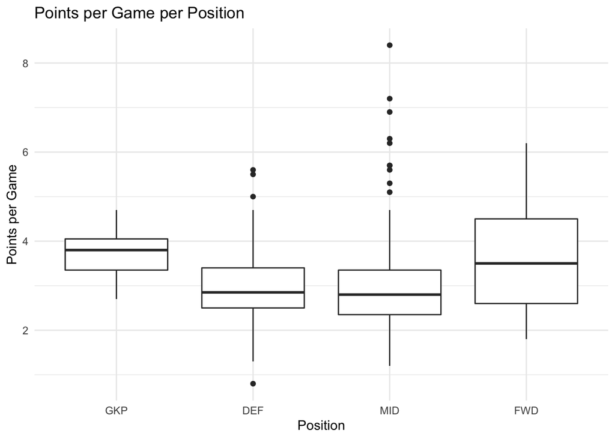

```r
ggplot(a[minutes>900,], aes(x=as.factor(element_type), y=as.numeric(points_per_game))) + geom_boxplot() + theme_minimal() + ylab("Points per Game") + xlab("Position") + ggtitle("Points per Game per Position")
```

Taking into account just players with over 900 minutes last seson we can see compare the points per game of across each position. Goalkeepers are the most stable position (although also the position with least players). Among qualified goalkeepers almost all fall within the 3-5 points per game range. Midfielders and defenders have similar averages but there is a longer tail of high-scoring midfielders. The top five scoring players in the game are all midfielders. Forwards have a wider range of points per game.

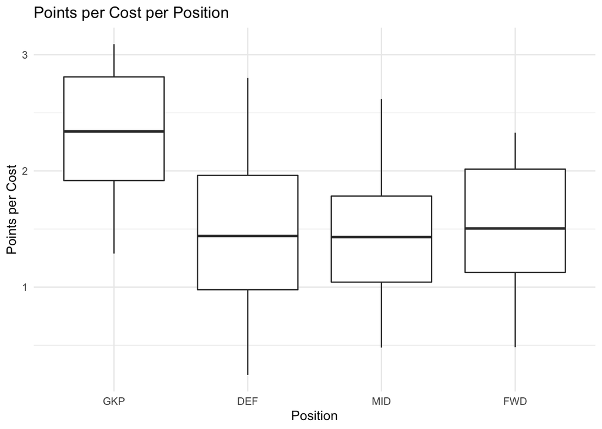

```r
ggplot(a[minutes>900,], aes(x=as.factor(element_type), y=as.numeric(points_per_cost))) + geom_boxplot() + theme_minimal() + ylab("Points per Cost") + xlab("Position") + ggtitle("Points per Cost per Position")
```

## Identifying top prospects

Plotting points per match vs. cost lets us evaluate the spread of options across price ranges and positions, and will show us the best value picks. Points per match is a useful stat as it does not harm players that were bought during last season, or players who were injured for parts of the 2019/20 seasons. To avoid any outliers who played only a few high-scoring games, for inclusion players must have played more than 900 minutes and accumulated more than 75 points last year.

Players are coloured according to their position type and isolines of points per cost are included to help determine value.

## Points per Match

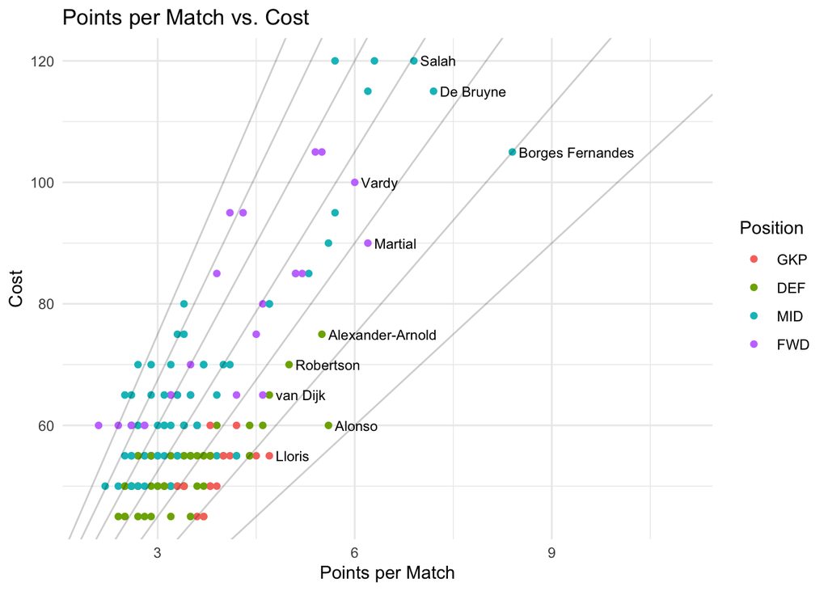

```r
(per_match <- (ggplot(a[(minutes>900)&(total_points>75)], aes(x = as.numeric(points_per_game), y = as.numeric(now_cost)))
  + geom_point(aes(colour=as.factor(element_type)))
  + geom_abline(intercept=0, slope=c(25,22.5,20,17.5,15,12.5,10), alpha=0.2)
  + theme_minimal()
  + xlab("Points per Match")
  + geom_text(aes(label=ifelse(second_name %in% c("De Bruyne", "Alexander-Arnold", "Vardy", "Martial", "Salah", "Robertson", "Alonso", "Borges Fernandes", "Lloris", "van Dijk"),second_name,"")),nudge_x = 0.1, hjust="left", size=3)
  + ylab("Cost")
  + xlim(2,11)
  + ggtitle("Points per Match vs. Cost")
  + labs(colour="Position")))
```

We can see from the chart that a most qualifying players fit in between 3 and 4.5 points per match (a longer tail of points per match less than 2 is excluded by our filter for inclusion).

The best value for money by points per match is Chelsea’s defender Alonso, although towards the end of last season he was only an occassional starter, so is worth treating with caution. Lloris, who spend some of last season injured rates highly in points per game relative to cost, and is an alternative to Burnley’s Pope (who ranks adjacent by these measures).

With midfielders and strikers there is more potential to separate from other players. Picking the right set of players in the top-right of the chart is crucial to performing well in FPL. Fernandes looks like a prime option, although having only played half of last season the 19/20 score may benefit from some favourable variation. Martial looks good value for only £9.0m cost, as do De Bruyne and Salah.

## Conclusion

This small analysis provides some guidance for constructing a team in Fantasy Premier League for 2020/21. A list of best value players is a good guide of who to look at for the new season, although at lower prices these players may need to be ignored until we know how changes affect playing time (e.g. with top-ranking Alonso). Optimising budget players is important, but a big difference can be derived from picking the right superstars to back during the season.

However, it is vital to keep an eye to changes between seasons, especially with many teams bringing in new signings, and newly promoted clubs joining the competition. After a month we might have enough data to consider readjustments to the team. From my perspective, I will be banking on Fernandes, Martial and De Bruyne to lead my team to victory - what could go wrong?